# Creating images with R

JPG to PNG conversion meme

name:Yifeng Deng UPI: yden299

```css
body {
  background-color: white;
  font-family: Arial;
  color: black;
}

h1, h2 {
  color: blue;
}

img {
  border: 3px solid red;
  border-radius: 10px;
  padding: 4px;
}

code {
  background-color: green;
}
```

## Project requirements

[figure not shown]

[My GitHub stats220 repo](https://github.com/aqige/stats220)

## Inspo meme

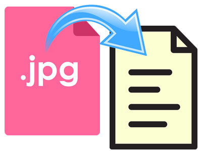

## My meme

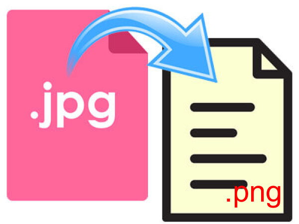

I changed the meme from the original design to a format-conversion theme. My meme uses a left-and-right comparison layout. The left side represents the original JPG format, while the right side represents the target png format after conversion.

This idea is simple, visually clear, and relevant to modern data technologies.

## My animated meme

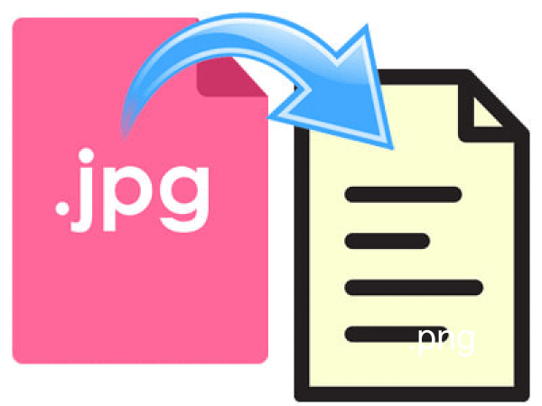

## Creativity

My project demonstrates creativity because : 1.I changed the original meme idea format from JPG and to PNG formats.

2.I also added animation to the meme by changing the size and colour of the text across multiple frames. 3. In addition, I used CSS to improve the appearance of the HTML report.

## Learning reflection

From Project 1, I learned:

1. Setting HTML styles using CSS. I add  
   to Separation of Content and Presentation,the CSS separates the structural content (HTML) from its visual design (fonts, colors, layout, etc.). This makes websites easier to read.

I have add CSS such as background-color,font-family, color,border ect ,those css provides features like text queries that allow web pages to adapt and render well.

2. Downloading image from website and processing images (scaling, annotating, pipelining), then changing their format and saving them locally. The images on the website varied in size and format. What I learned was to download images from external websites, resize them to a fixed size so that the coordinates for adding text were consistent, and then save them in a uniform PNG format for easier subsequent processing. This is my approach to image data cleaning.
3. Understanding GIF images and animations, creating a 4-frame GIF, adding text, and having the text change size and color within the animation.

## Appendix

Do not change, edit, or remove the `R` chunk included below.

If you are working within RStudio and within your Project1 RStudio project (check the top right-hand corner says “Project1”), then the code from the `meme.R` script will be displayed below.

This code needs to be visible for your project to be marked appropriately, as some of the criteria are based on this code being submitted.

```r
# load magick library
library(magick)

#read image
img <-image_read(path = "https://www.easetext.com/assets/img/tutorial/jpg-to-text.jpg")
#show original image size
image_info(img)


# -------------------------
# Part D: Create static meme
# -------------------------

#rescale image size to 600*450,then add red text png as image result format.
meme <- img %>%
  image_scale("600x450")%>%
  image_annotate(
    ".png",
    size = 60,
    color = "red",
    location = "+450+350"
  )

#save image as my_meme.png
meme %>%
  image_write("my_meme.png")

# -------------------------
# Part E: Adding animation
# -------------------------

# Create frame 1
frame1 <- img %>%
  image_scale("600x450")%>%
  image_annotate(
    ".png",
    size = 40,
    color = "white",
    location = "+450+350"
  )

# Create frame 2
frame2 <- img %>%
  image_scale("600x450")%>%
  image_annotate(
    ".png",
    size = 50,
    color = "red",
    location = "+450+350"
  )

# Create frame 3
frame3 <- img %>%
  image_scale("600x450")%>%
  image_annotate(
    ".png",
    size = 60,
    color = "blue",
    location = "+450+350"
  )

# Create frame 4
frame4 <- img %>%
  image_scale("600x450")%>%
  image_annotate(
    ".png",
    size = 70,
    color = "green",
    location = "+450+350"
  )

# Combine frames into one animation object
frames <- c(frame1, frame2, frame3, frame4)

# Animate the frames
animation <- frames %>%
  image_animate(fps = 1)

# Save the animated GIF
animation %>%
  image_write("my_animated_meme.gif")
```